# Reproducible Research, Project 1

##### General / loading dependencies etc

```r
rm(list=ls())
library(dplyr)
library(ggplot2)
library(gridExtra)
options(scipen=999) # displaying integers without scientific notation
```

##### Question 1, reading data

```r
dat <- read.csv("activity.csv",head=T)
# dat$date <- as.POSIXct(dat$date,"%Y-%m-%d",tz="GMT")
```

##### Question 2, histogram of the total number of steps take each day

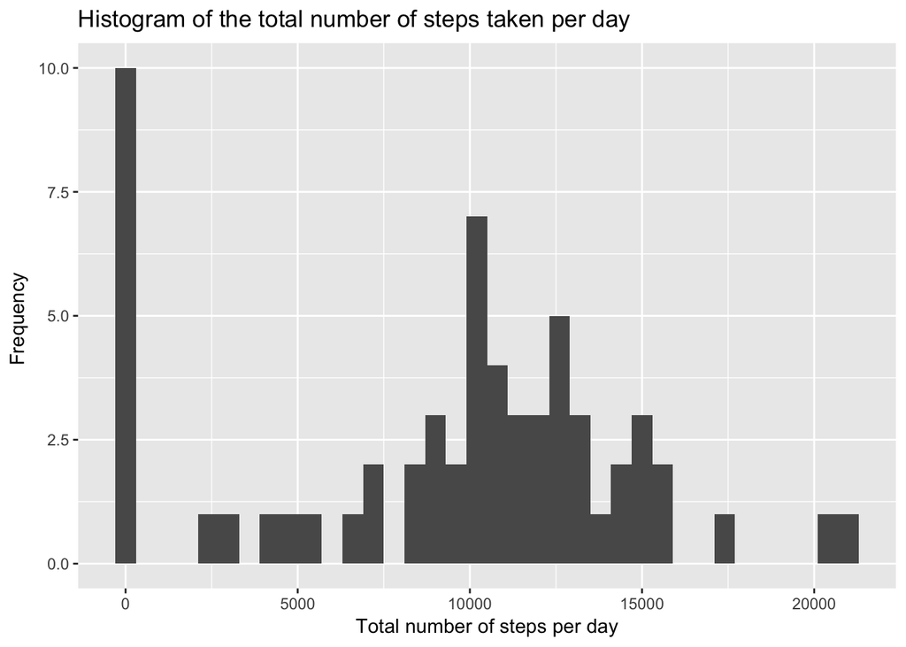

```r
steps <-  dat %>% group_by(date) %>% summarise(steps.per.date=sum(steps,na.rm=T))
ggplot(data=steps, aes(steps.per.date))+
      geom_histogram(binwidth = 600)+
      labs(x="Total number of steps per day",y="Frequency ")+
      ggtitle("Histogram of the total number of steps taken per day")
```

##### Question 3, mean and median of steps taken each day

```r
mean(steps$steps.per.date)
median(steps$steps.per.date)
```

Mean of steps taken each day is 9354 and the Median is 10395

##### Question 4, time series plot of the average number of steps taken

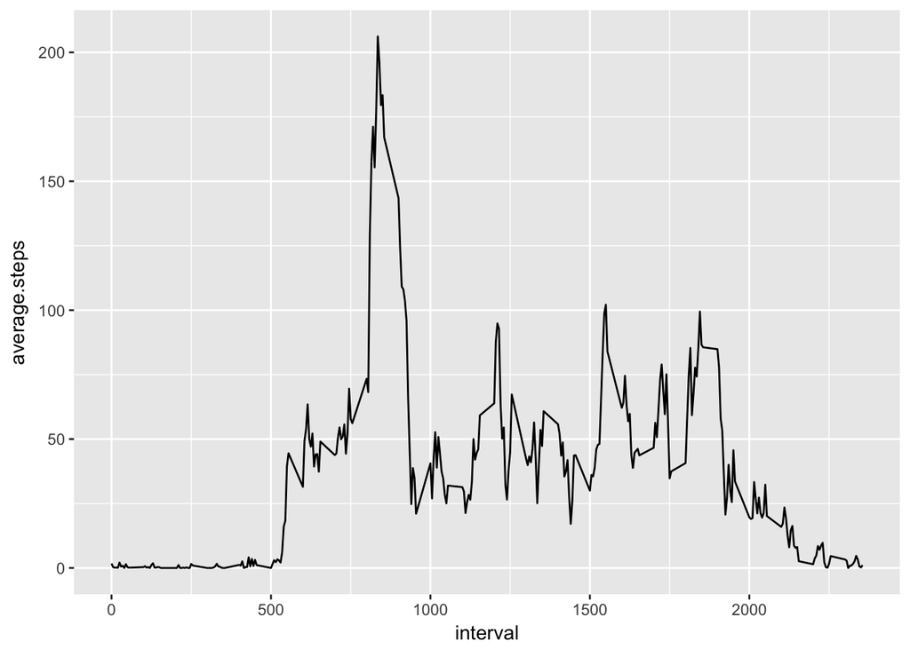

```r
avg.steps.per.interval <-
      dat %>%
      group_by(interval) %>%
      summarise(average.steps=mean(steps,na.rm=T))

ggplot(data=avg.steps.per.interval,aes(interval,average.steps))+
      geom_line()
```

##### Question 5, the 5-minute interval that, on average, contains the maximum number of steps

```r
max.interval <- subset(avg.steps.per.interval,avg.steps.per.interval$average.steps==max(avg.steps.per.interval$average.steps))
```

So interval 835 is the period with the highest activity. It corresponds well with the peak on the graph from question 4. The average number of steps in that period was 206 steps

##### Question 6 and 7, code to describe and show a strategy for imputing missing data and Histogram

In the data set there are 2304 missing values which corresponds to around 4.37% of the entire data set.

Again using the dplyr package:

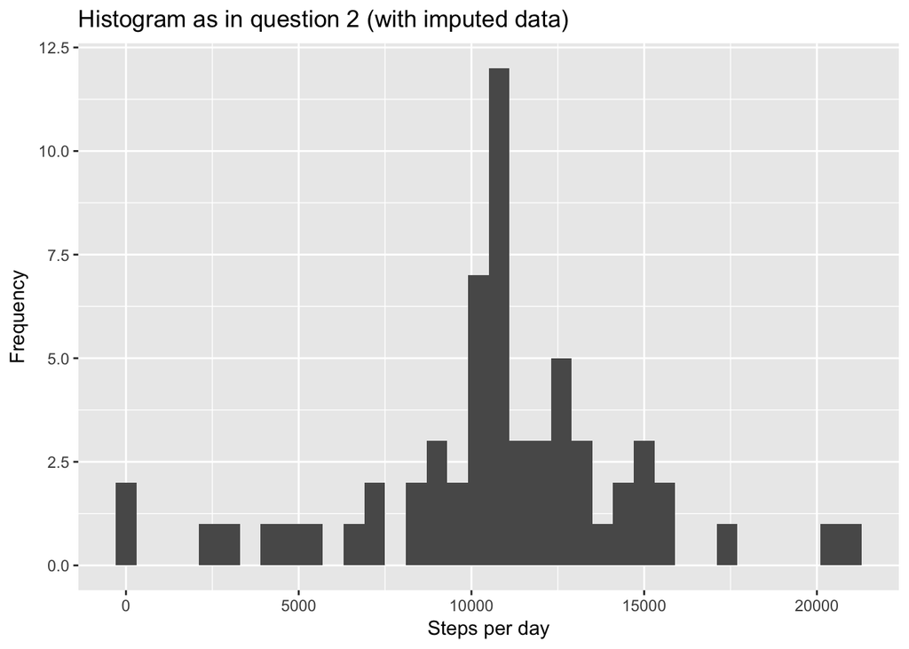

```r
imp <- inner_join(dat, avg.steps.per.interval, by="interval") %>%
      mutate(steps=ifelse(is.na(steps),average.steps,steps)) %>%
      select(date,interval, steps)

dat.imp <-
      imp %>%
      group_by(date) %>%
      summarise(steps.per.day.imp = sum(steps))
ggplot(data=dat.imp,aes(steps.per.day.imp))+
      geom_histogram(binwidth = 600)+
      labs(x="Steps per day",y="Frequency")+
      ggtitle("Histogram as in question 2 (with imputed data)")
```

Calculating mean and median after imputation.

```r
imp.dat2 <-
      imp %>%
      group_by(date) %>%
      summarise(steps.per.date=sum(steps,na.rm=T))
mean(imp.dat2$steps.per.date)
```

```
## [1] 10766.19
```

```r
median(imp.dat2$steps.per.date)
```

```
## [1] 10766.19
```

##### Question 8, panel plot comparing the average number of steps taken per 5-minute interval across weekdays and weekends

Using the imputed data to look at the differences between weekday activity and weekend activity.

```r
imp$date <- as.POSIXct(imp$date)
imp$day <- weekdays(imp$date)
day.interval <-
      imp %>%
      group_by(interval,day) %>%
      summarise(mean.w.day=mean(steps,na.rm=T))
```

Dividing days into weekdays and weekend-days

```r
weekday <- filter(day.interval, day=="Monday" | day== "Tuesday" | day == "Wednesday" | day == "Thursday" | day == "Friday")
weekendday <- filter(day.interval, day=="Saturday" | day == "Sunday")
```

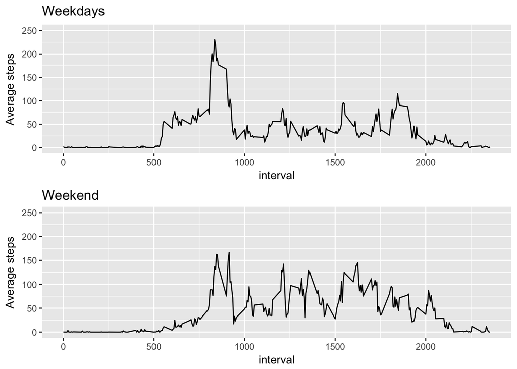

```r
weekday.dat <-
      weekday %>%
      group_by(interval) %>%
      summarise(var1=mean(mean.w.day))
weekday.gg <- ggplot(data=weekday.dat, aes(interval, var1))+geom_line()+ylim(c(0,250))+ylab("Average steps")+ggtitle("Weekdays")

weekendday.dat <-
      weekendday %>%
      group_by(interval) %>%
      summarise(var2=mean(mean.w.day))
weekendday.gg <- ggplot(data=weekendday.dat,aes(interval,var2))+geom_line()+ylim(c(0,250))+ylab("Average steps")+ggtitle("Weekend")

grid.arrange(weekday.gg,weekendday.gg,nrow=2)
```